# Sensitivity Analysis for Conservation Decision-Making

Which parameter drives Ne/N most — and what can a manager actually change?

Raymond L. Tremblay

2026-03-08

# 1 Introduction

## 1.1 From a ratio to a decision

The previous vignette (*NeStage Functions: A User Guide*) established that all three *Lepanthes* orchid species in Puerto Rico have Ne/N ratios far below the short-term inbreeding threshold of Ne ≥ 50, even at census sizes of N = 40 — a large population for these species. Knowing that Ne/N = 0.18 for a particular population tells you the situation is serious. It does not tell you **what to do about it**.

Sensitivity analysis answers the management question: **which parameter, if changed, would increase Ne/N the most?** This matters because managers have limited resources and can realistically influence only certain aspects of a population’s biology:

| What a manager can influence | Relevant parameter |
| --- | --- |
| Reducing harvest or disturbance of reproductive adults | Stage frequency D — more adults |
| Translocating individuals between populations | Census N, D |
| Ex-situ propagation with controlled pollination | Reproductive variance Vk/k̄ |
| Removing dominant clonal genets | Clonal fraction d, Vc/c̄ |
| Improving habitat to extend plant lifespan | Generation time L |

## 1.2 The four sensitivity functions

`NeStage` provides four sensitivity functions, each sweeping one parameter while holding all others fixed:

| Function | Parameter swept | Applies to |
| --- | --- | --- |
| `Ne_sensitivity_Vk()` | Sexual reproductive variance Vk/k̄ | Sexual, mixed |
| `Ne_sensitivity_Vc()` | Clonal reproductive variance Vc/c̄ | Mixed only |
| `Ne_sensitivity_d()` | Clonal fraction d | Mixed only |
| `Ne_sensitivity_L()` | Generation time L | All three models |

Each function returns a data frame, a ggplot, and an `Ne_sensitivity` object with elasticity statistics from `print()`.

## 1.3 Elasticity: a standardised sensitivity measure

Raw sensitivity (how much does Ne/N change per unit change in a parameter) is hard to compare across parameters measured in different units. **Elasticity** standardises by expressing the response as a proportional change:

$$E = \frac{\partial (N_e/N)}{\partial \theta} \times
\frac{\theta_\text{ref}}{(N_e/N)_\text{ref}}$$

An elasticity of −0.4 means a 10% increase in $\theta$ produces a 4% decrease in Ne/N. Elasticities are dimensionless and directly comparable across parameters and populations.

# 2 Study populations

We use three representative *Lepanthes* populations from the previous vignette — one from each species — chosen to span the range of Ne/N values observed.

```r
# ---- L. rupestris population 1 (Ne/N = 0.572) ----
MatU_Lrup1 <- matrix(c(
  0,     0,     0,     0,     0,     0,
  0.738, 0.738, 0,     0,     0,     0,
  0,     0,     0.515, 0,     0.076, 0.013,
  0,     0.038, 0,     0.777, 0,     0,
  0,     0.002, 0.368, 0.011, 0.730, 0.171,
  0,     0,     0.037, 0,     0.169, 0.790
), nrow = 6, byrow = TRUE,
dimnames = list(paste0("s", 1:6), paste0("s", 1:6)))

F_Lrup1 <- c(0, 0, 0, 0, 0.120, 0.414)   # monthly fecundity
D_Lrup1 <- c(22, 22, 36, 36, 48.5, 48.5)
D_Lrup1 <- D_Lrup1 / sum(D_Lrup1)

# ---- L. rubripetala population 1 (Ne/N = 0.930) ----
MatU_Lrub1 <- matrix(c(
  0,     0,     0,     0,     0,
  0.667, 0.667, 0,     0,     0,
  0,     0,     0.825, 0,     0.227,
  0,     0.037, 0,     0.812, 0,
  0,     0,     0.137, 0.010, 0.739
), nrow = 5, byrow = TRUE,
dimnames = list(paste0("s", 1:5), paste0("s", 1:5)))

F_Lrub1 <- c(0, 0, 0, 0, 0.043)
N_Lrub1 <- c(9/2, 9/2, 44/2, 44/2, 101)
D_Lrub1 <- N_Lrub1 / sum(N_Lrub1)

# ---- L. rubripetala population 5 (Ne/N = 0.250, lowest in Lrub) ----
MatU_Lrub5 <- matrix(c(
  0,     0,     0,     0,     0,
  0.667, 0.667, 0,     0,     0,
  0,     0,     0.726, 0,     0.250,
  0,     0.037, 0,     0.812, 0,
  0,     0,     0.237, 0.010, 0.739
), nrow = 5, byrow = TRUE,
dimnames = list(paste0("s", 1:5), paste0("s", 1:5)))

F_Lrub5 <- c(0, 0, 0, 0, 0.067)
N_Lrub5 <- c(52/2, 52/2, 4/2, 4/2, 46)
D_Lrub5 <- N_Lrub5 / sum(N_Lrub5)

# Baseline Ne estimates for reference
Ne_base_Lrup1 <- Ne_sexual_Y2000(
  T_mat = MatU_Lrup1, F_vec = F_Lrup1, D = D_Lrup1,
  Ne_target = 50, census_N = 40, population = "L. rupestris pop 1"
)
Ne_base_Lrub1 <- Ne_sexual_Y2000(
  T_mat = MatU_Lrub1, F_vec = F_Lrub1, D = D_Lrub1,
  Ne_target = 50, census_N = 40, population = "L. rubripetala pop 1"
)
Ne_base_Lrub5 <- Ne_sexual_Y2000(
  T_mat = MatU_Lrub5, F_vec = F_Lrub5, D = D_Lrub5,
  Ne_target = 50, census_N = 40, population = "L. rubripetala pop 5"
)

# Baseline summary
data.frame(
  Population = c("L. rupestris pop 1", "L. rubripetala pop 1",
                 "L. rubripetala pop 5"),
  Stages     = c(6, 5, 5),
  NeN        = round(c(Ne_base_Lrup1$NeN, Ne_base_Lrub1$NeN,
                        Ne_base_Lrub5$NeN), 3),
  Ne_at_40   = c(Ne_base_Lrup1$Ne_at_census, Ne_base_Lrub1$Ne_at_census,
                  Ne_base_Lrub5$Ne_at_census),
  Min_N_50   = c(Ne_base_Lrup1$Min_N, Ne_base_Lrub1$Min_N,
                  Ne_base_Lrub5$Min_N)
) |>
  knitr::kable(
    col.names = c("Population", "Stages", "Ne/N",
                  "Ne at N=40", "Min N (Ne≥50)"),
    caption   = "Baseline Ne/N estimates for the three study populations
                 (monthly matrices, Ne_target = 50, census_N = 40)."
  )
```

Baseline Ne/N estimates for the three study populations (monthly matrices, Ne_target = 50, census_N = 40).

| Population | Stages | Ne/N | Ne at N=40 | Min N (Ne≥50) |
| --- | --- | --- | --- | --- |
| L. rupestris pop 1 | 6 | 0.572 | 22.9 | 88 |
| L. rubripetala pop 1 | 5 | 0.930 | 37.2 | 54 |
| L. rubripetala pop 5 | 5 | 0.250 | 10.0 | 201 |

# 3 Sensitivity to sexual reproductive variance: `Ne_sensitivity_Vk()`

## 3.1 What is Vk/k̄ and why does it matter?

The variance-to-mean ratio of sexual reproductive output Vk/k̄ measures how equally seeds are distributed among reproductive adults. Under Poisson distribution (Vk/k̄ = 1), all adults contribute equally to the seed pool. Values above 1 mean some individuals dominate — a few adults produce most of the seeds, so the effective number of parents is smaller than the census count.

In *Lepanthes*, this is biologically plausible because:

- Pollination by fungus gnats is patchy — some plants are visited far more frequently than others
- Microhabitat variation means some individuals are far more fecund than others
- In small populations, one or two dominant individuals can produce most seeds in a given year

The Poisson default (Vk/k̄ = 1) is almost certainly an underestimate of the true variance for most natural populations.

## 3.2 Running `Ne_sensitivity_Vk()` for the reproductive stage

For *L. rupestris* (6 stages), stage 5 (single-shoot reproductive adults) is the primary sexual reproductive stage. We sweep Vk/k̄ from 0.5 to 8.

```r
sens_Vk_Lrup1 <- Ne_sensitivity_Vk(
  model_fn    = Ne_sexual_Y2000,
  T_mat       = MatU_Lrup1,
  F_vec       = F_Lrup1,
  D           = D_Lrup1,
  stage_index = 5,              # stage 5: single-shoot reproductive adults
  Vk_range    = seq(0.5, 8, by = 0.5),
  Ne_target   = 50,
  population  = "L. rupestris pop 1"
)

print(sens_Vk_Lrup1)
```

```
#>
#> === NeStage Sensitivity Analysis ===
#>   Parameter swept  : Vk/k_bar (sexual reproductive variance)
#>   Focal stage      : s5
#>   Model            : Ne_sexual_Y2000
#>   Population       : L. rupestris pop 1
#>
#>   --- Range swept ---
#>     Vk_over_k from 0.5 to 8  (16 values)
#>
#>   --- Ne/N summary ---
#>     At reference (Vk_over_k = 1)  : Ne/N = 0.572  |  Min N = 88
#>     Maximum Ne/N  (Vk_over_k = 0.5)  : Ne/N = 0.604  |  Min N = 83
#>     Minimum Ne/N  (Vk_over_k = 8)  : Ne/N = 0.331  |  Min N = 152
#>     Ne/N range across sweep  : 0.273
#>
#>   --- Elasticity (Caswell 2001; Morris & Doak 2002) ---
#>     Local elasticity at reference point : E = -0.104
#>     Global elasticity (mean over range) : E = 0.285
#>
#>     Interpretation (local elasticity):
#>       A 10% increase in Vk_over_k at the reference point
#>       produces a 1.0% change in Ne/N.
#>       Direction: NEGATIVE -- higher variance reduces Ne/N (typical)
#>
#>   --- Conservation implications ---
#>     Min N at reference point             : 88
#>     Min N at worst case (Vk_over_k = 8)  : 152
#>     Ratio worst/reference                : 1.7x more individuals
#>     Ne target used                       : 50
#>
#>   --- Comparison to empirical Ne/N (Frankham 1995) ---
#>     Ne/N at reference (0.572) is ABOVE the empirical median of ~0.10
#>     across 102 wildlife species (Frankham 1995). This population
#>     has relatively high effective size.
#>     Frankham (1995) empirical range: 0.01 -- 0.99
#>
#>   --- References ---
#>     Caswell H. (2001). Matrix Population Models, 2nd ed.
#>       Sinauer Associates. [elasticity methodology]
#>     Morris W.F. & Doak D.F. (2002). Quantitative Conservation
#>       Biology. Sinauer Associates. Ch. 9. [sensitivity analysis]
#>     Frankham R. (1995). Effective population size/adult population
#>       size ratios in wildlife: a review.
#>       Genetical Research 66: 95-107. [Ne/N empirical benchmarks]
#>     Yonezawa et al. (2000). Evolution 54(6): 2007-2013. [model]
```

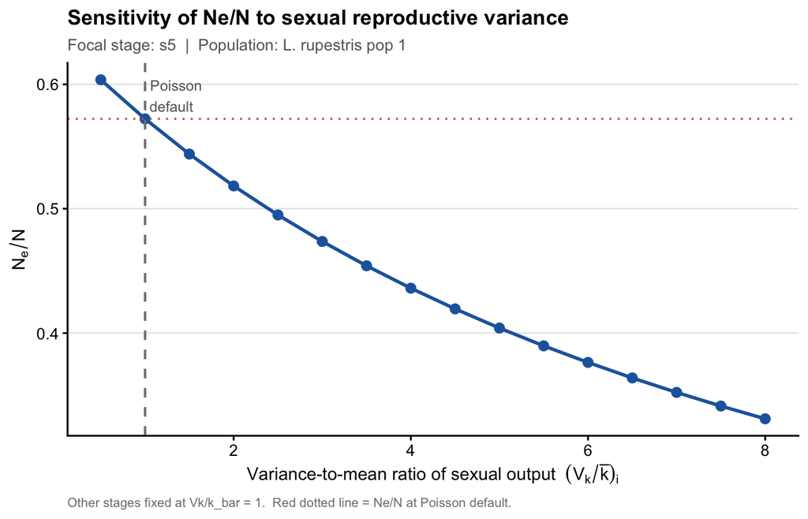

Sensitivity of Ne/N to sexual reproductive variance in stage 5 of *L. rupestris* pop 1. Dashed vertical line = Poisson default.

## 3.3 Interpretation

The elasticity printed above tells us how strongly Ne/N responds to Vk/k̄. A negative local elasticity is expected — higher reproductive variance always reduces Ne/N. The conservation ratio (worst-case Ne/N relative to Poisson baseline) tells a manager: if reproductive inequality is at the high end of the plausible range, how many more individuals are needed?

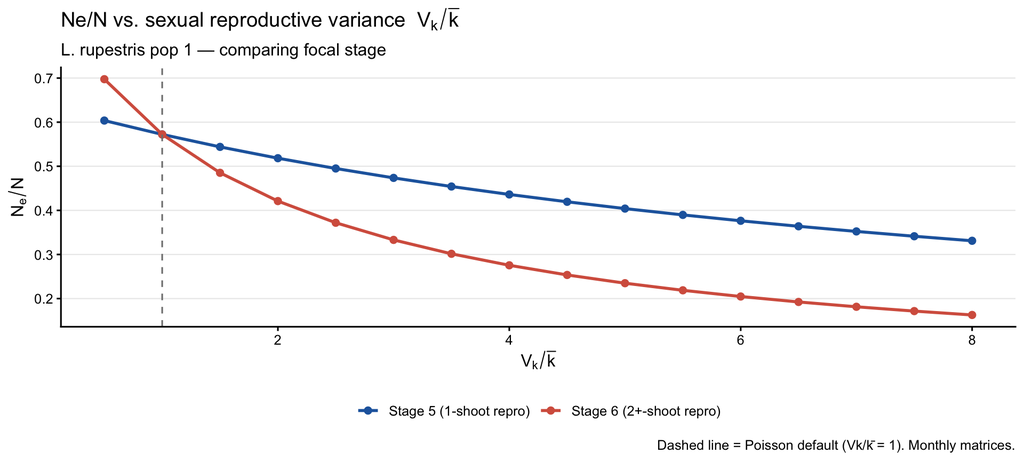

```r
# Also sweep stage 6 (two-or-more-shoot adults) for comparison
sens_Vk_Lrup1_s6 <- Ne_sensitivity_Vk(
  model_fn    = Ne_sexual_Y2000,
  T_mat       = MatU_Lrup1,
  F_vec       = F_Lrup1,
  D           = D_Lrup1,
  stage_index = 6,
  Vk_range    = seq(0.5, 8, by = 0.5),
  Ne_target   = 50,
  population  = "L. rupestris pop 1 — stage 6"
)

# Combined data for comparison plot
df_vk_compare <- bind_rows(
  sens_Vk_Lrup1$data    %>% mutate(Stage = "Stage 5 (1-shoot repro)"),
  sens_Vk_Lrup1_s6$data %>% mutate(Stage = "Stage 6 (2+-shoot repro)")
)

ggplot(df_vk_compare, aes(x = Vk_over_k, y = NeN, color = Stage)) +
  geom_line(linewidth = 1) +
  geom_point(size = 2) +
  geom_vline(xintercept = 1, linetype = "dashed", color = "grey50") +
  scale_color_manual(values = c("#2166ac", "#d6604d")) +
  labs(
    title    = expression(paste("Ne/N vs. sexual reproductive variance  ", V[k]/bar(k))),
    subtitle = "L. rupestris pop 1 — comparing focal stage",
    x        = expression(V[k]/bar(k)),
    y        = expression(N[e]/N),
    color    = NULL,
    caption  = "Dashed line = Poisson default (Vk/k̄ = 1). Monthly matrices."
  ) +
  theme_classic(base_size = 12) +
  theme(
    plot.title = element_text(face = "bold"),
    legend.position = "bottom",
    panel.grid.major.y = element_line(color = "grey92", linewidth = 0.4)
  )
```

Stage 6 (multi-shoot plants) has a larger effect because its fecundity (F = 0.414 per month) is more than three times that of stage 5 (F = 0.120). When high-fecundity adults have unequal reproductive output, the genetic consequences are proportionally larger.

**Management implication:** Strategies that equalise seed production — for example, hand-pollination programmes that ensure all reproductive adults contribute pollen — would have the greatest effect in stage 6 individuals.

# 4 Sensitivity to generation time: `Ne_sensitivity_L()`

## 4.2 Sweeping L across a biologically plausible range

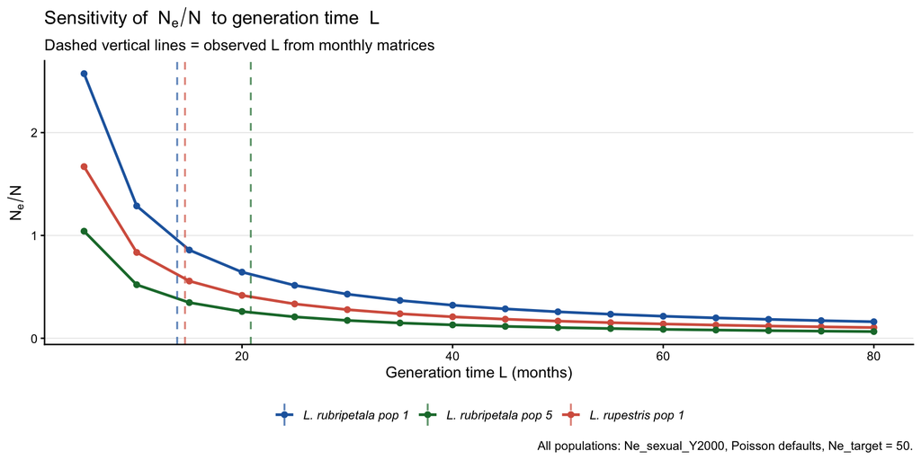

Sensitivity of Ne/N to generation time L across all three study populations.

```r
L_range_use <- seq(5, 80, by = 5)

# Run for all three populations
make_L_sens <- function(MatU, F_vec, D, Ne_target, pop_label) {
  Ne_sensitivity_L(
    model_fn   = Ne_sexual_Y2000,
    T_mat      = MatU,
    F_vec      = F_vec,
    D          = D,
    L_range    = L_range_use,
    Ne_target  = Ne_target,
    population = pop_label
  )
}

sens_L_Lrup1 <- make_L_sens(MatU_Lrup1, F_Lrup1, D_Lrup1, 50,
                              "L. rupestris pop 1")
sens_L_Lrub1 <- make_L_sens(MatU_Lrub1, F_Lrub1, D_Lrub1, 50,
                              "L. rubripetala pop 1")
sens_L_Lrub5 <- make_L_sens(MatU_Lrub5, F_Lrub5, D_Lrub5, 50,
                              "L. rubripetala pop 5")

# Observed L values from monthly matrices
L_obs <- c(Ne_base_Lrup1$L, Ne_base_Lrub1$L, Ne_base_Lrub5$L)

df_L <- bind_rows(
  sens_L_Lrup1$data %>% mutate(Population = "L. rupestris pop 1",
                                 L_obs = L_obs[1]),
  sens_L_Lrub1$data %>% mutate(Population = "L. rubripetala pop 1",
                                 L_obs = L_obs[2]),
  sens_L_Lrub5$data %>% mutate(Population = "L. rubripetala pop 5",
                                 L_obs = L_obs[3])
)

ggplot(df_L, aes(x = L, y = NeN, color = Population)) +
  geom_line(linewidth = 1) +
  geom_point(size = 1.8) +
  geom_vline(aes(xintercept = L_obs, color = Population),
             linetype = "dashed", linewidth = 0.7, alpha = 0.7) +
  scale_color_manual(values = c("#2166ac", "#1b7837", "#d6604d")) +
  labs(
    title    = expression(paste("Sensitivity of  ", N[e]/N, "  to generation time  ", L)),
    subtitle = "Dashed vertical lines = observed L from monthly matrices",
    x        = "Generation time L (months)",
    y        = expression(N[e]/N),
    color    = NULL,
    caption  = "All populations: Ne_sexual_Y2000, Poisson defaults, Ne_target = 50."
  ) +
  theme_classic(base_size = 12) +
  theme(
    plot.title      = element_text(face = "bold"),
    legend.position = "bottom",
    legend.text     = element_text(face = "italic"),
    panel.grid.major.y = element_line(color = "grey92", linewidth = 0.4)
  )
```

```r
# Print elasticity summary for the most sensitive population
print(sens_L_Lrub5)
```

```
#>
#> === NeStage Sensitivity Analysis ===
#>   Parameter swept  : L (generation time, years)
#>   Model            : Ne_sexual_Y2000
#>   Population       : L. rubripetala pop 5
#>
#>   --- Range swept ---
#>     L from 5 to 80  (16 values)
#>
#>   --- Ne/N summary ---
#>     At reference (L = 20.833)  : Ne/N = 0.260  |  Min N = 193
#>     Maximum Ne/N  (L = 5)  : Ne/N = 1.041  |  Min N = 49
#>     Minimum Ne/N  (L = 80)  : Ne/N = 0.065  |  Min N = 769
#>     Ne/N range across sweep  : 0.976
#>
#>   --- Elasticity (Caswell 2001; Morris & Doak 2002) ---
#>     Local elasticity at reference point : E = -1.111
#>     Global elasticity (mean over range) : E = 0.841
#>
#>     Interpretation (local elasticity):
#>       A 10% increase in L at the reference point
#>       produces a 11.1% change in Ne/N.
#>       Direction: NEGATIVE -- higher variance reduces Ne/N (typical)
#>
#>   --- Conservation implications ---
#>     Min N at reference point             : 193
#>     Min N at worst case (L = 80)  : 769
#>     Ratio worst/reference                : 4.0x more individuals
#>     Ne target used                       : 50
#>
#>   --- Comparison to empirical Ne/N (Frankham 1995) ---
#>     Ne/N at reference (0.26) is near the empirical median of ~0.10
#>     across 102 wildlife species (Frankham 1995).
#>     Frankham (1995) empirical range: 0.01 -- 0.99
#>
#>   --- References ---
#>     Caswell H. (2001). Matrix Population Models, 2nd ed.
#>       Sinauer Associates. [elasticity methodology]
#>     Morris W.F. & Doak D.F. (2002). Quantitative Conservation
#>       Biology. Sinauer Associates. Ch. 9. [sensitivity analysis]
#>     Frankham R. (1995). Effective population size/adult population
#>       size ratios in wildlife: a review.
#>       Genetical Research 66: 95-107. [Ne/N empirical benchmarks]
#>     Yonezawa et al. (2000). Evolution 54(6): 2007-2013. [model]
```

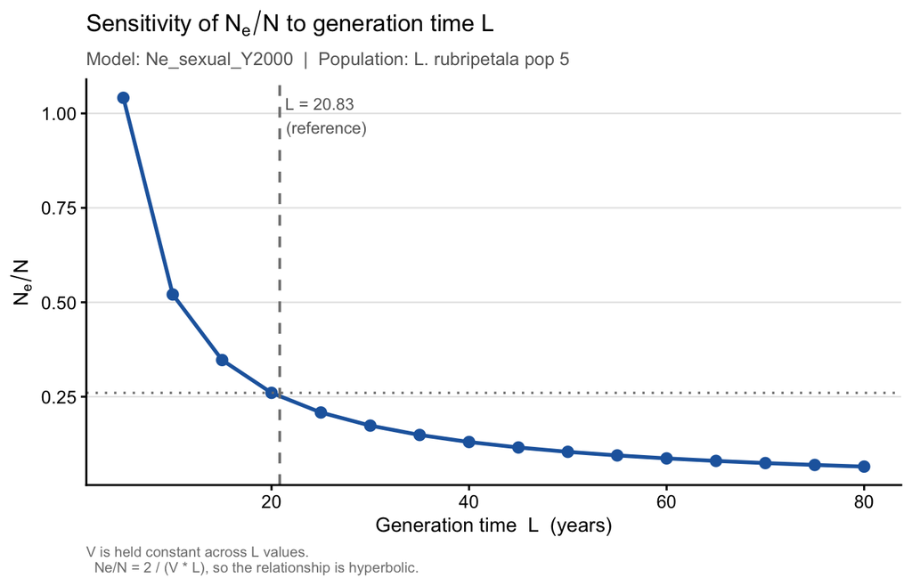

## 4.3 Key insight: Ne/N is hyperbolic in L

**Management implication:** For populations where L is highly uncertain, it is worth investing in longer-term demographic monitoring (ideally ≥ 5 years) to pin down L more precisely before interpreting Ne/N.

# 5 Sensitivity to clonal fraction: `Ne_sensitivity_d()`

## 5.1 When does clonal fraction matter?

A fundamental and counter-intuitive result of Yonezawa et al. (2000) is that **under Poisson defaults (Vc/c̄ = Vk/k̄ = 1), the clonal fraction d has no effect on Ne/N**. This is because when all individuals reproduce equally (whether sexually or clonally), the mode of reproduction does not matter for genetic drift.

Clonal fraction only reduces Ne/N when **clonal output is more variable than sexual output** — when some genets dominate clonal reproduction, reducing the number of genetically distinct lineages. We demonstrate both cases here using a hypothetical mixed-reproduction *Lepanthes* population.

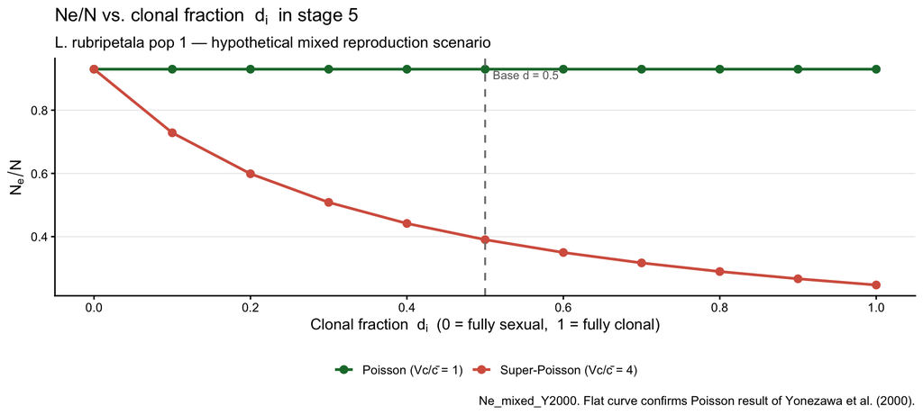

```r
# Use L. rubripetala pop 1 matrix structure with a mixed reproduction scenario
# Add a clonal component: imagining a hypothetical scenario where stage 5
# (reproductive adults) can reproduce clonally via offshoots

# Poisson case — d has no effect
sens_d_poisson <- Ne_sensitivity_d(
  T_mat       = MatU_Lrub1,
  F_vec       = F_Lrub1,
  D           = D_Lrub1,
  d_fixed     = c(0, 0, 0, 0, 0.5),   # base: stage 5 is 50% clonal
  stage_index = 5,
  d_range     = seq(0, 1, by = 0.1),
  Vc_over_c   = rep(1, 5),             # Poisson clonal variance
  Ne_target   = 50,
  population  = "L. rubripetala pop 1 (Poisson)"
)

# Super-Poisson clonal variance — d starts to matter
sens_d_superpoisson <- Ne_sensitivity_d(
  T_mat       = MatU_Lrub1,
  F_vec       = F_Lrub1,
  D           = D_Lrub1,
  d_fixed     = c(0, 0, 0, 0, 0.5),
  stage_index = 5,
  d_range     = seq(0, 1, by = 0.1),
  Vc_over_c   = c(1, 1, 1, 1, 4),     # stage 5 clonal output highly variable
  Ne_target   = 50,
  population  = "L. rubripetala pop 1 (Vc/c̄ = 4)"
)

df_d <- bind_rows(
  sens_d_poisson$data      %>% mutate(Scenario = "Poisson (Vc/c̄ = 1)"),
  sens_d_superpoisson$data %>% mutate(Scenario = "Super-Poisson (Vc/c̄ = 4)")
)

ggplot(df_d, aes(x = d_focal, y = NeN, color = Scenario)) +
  geom_line(linewidth = 1) +
  geom_point(size = 2.5) +
  geom_vline(xintercept = 0.5, linetype = "dashed",
             color = "grey50", linewidth = 0.7) +
  annotate("text", x = 0.51, y = max(df_d$NeN) * 0.98,
           label = "Base d = 0.5", hjust = 0, size = 3.2, color = "grey40") +
  scale_color_manual(values = c("#1b7837", "#d6604d")) +
  scale_x_continuous(breaks = seq(0, 1, by = 0.2)) +
  labs(
    title    = expression(paste("Ne/N vs. clonal fraction  ", d[i], "  in stage 5")),
    subtitle = "L. rubripetala pop 1 — hypothetical mixed reproduction scenario",
    x        = expression(paste("Clonal fraction  ", d[i],
                                "  (0 = fully sexual,  1 = fully clonal)")),
    y        = expression(N[e]/N),
    color    = NULL,
    caption  = "Ne_mixed_Y2000. Flat curve confirms Poisson result of Yonezawa et al. (2000)."
  ) +
  theme_classic(base_size = 12) +
  theme(
    plot.title      = element_text(face = "bold"),
    legend.position = "bottom",
    panel.grid.major.y = element_line(color = "grey92", linewidth = 0.4)
  )
```

```r
print(sens_d_superpoisson)
```

```
#>
#> === NeStage Sensitivity Analysis ===
#>   Parameter swept  : d (clonal fraction)
#>   Focal stage      : s5
#>   Model            : Ne_mixed_Y2000
#>   Population       : L. rubripetala pop 1 (Vc/c̄ = 4)
#>
#>   --- Range swept ---
#>     d_focal from 0 to 1  (11 values)
#>
#>   --- Ne/N summary ---
#>     At reference (d_focal = 0.5)  : Ne/N = 0.390  |  Min N = 129
#>     Maximum Ne/N  (d_focal = 0)  : Ne/N = 0.930  |  Min N = 54
#>     Minimum Ne/N  (d_focal = 1)  : Ne/N = 0.247  |  Min N = 203
#>     Ne/N range across sweep  : 0.682
#>
#>   --- Elasticity (Caswell 2001; Morris & Doak 2002) ---
#>     Local elasticity at reference point : E = -0.588
#>     Global elasticity (mean over range) : E = 0.432
#>
#>     Interpretation (local elasticity):
#>       A 10% increase in d_focal at the reference point
#>       produces a 5.9% change in Ne/N.
#>       Direction: NEGATIVE -- higher variance reduces Ne/N (typical)
#>
#>   --- Conservation implications ---
#>     Min N at reference point             : 129
#>     Min N at worst case (d_focal = 1)  : 203
#>     Ratio worst/reference                : 1.6x more individuals
#>     Ne target used                       : 50
#>
#>   --- Comparison to empirical Ne/N (Frankham 1995) ---
#>     Ne/N at reference (0.39) is ABOVE the empirical median of ~0.10
#>     across 102 wildlife species (Frankham 1995). This population
#>     has relatively high effective size.
#>     Frankham (1995) empirical range: 0.01 -- 0.99
#>
#>   --- References ---
#>     Caswell H. (2001). Matrix Population Models, 2nd ed.
#>       Sinauer Associates. [elasticity methodology]
#>     Morris W.F. & Doak D.F. (2002). Quantitative Conservation
#>       Biology. Sinauer Associates. Ch. 9. [sensitivity analysis]
#>     Frankham R. (1995). Effective population size/adult population
#>       size ratios in wildlife: a review.
#>       Genetical Research 66: 95-107. [Ne/N empirical benchmarks]
#>     Yonezawa et al. (2000). Evolution 54(6): 2007-2013. [model]
```

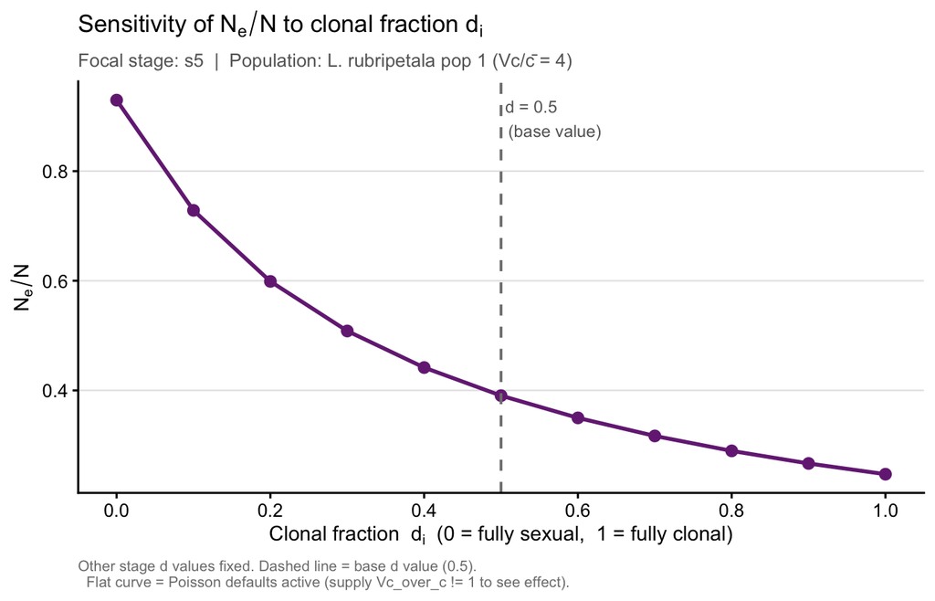

**Management implication:** Simply removing clonal propagules (to reduce d) has no genetic benefit under Poisson variance assumptions. The conservation benefit of managing clonal reproduction comes only when dominant genets can be identified and their disproportionate contribution to the clonal pool reduced — which requires molecular markers to identify genets in the field.

# 6 Cross-parameter comparison: which lever matters most?

We now compare the local elasticities across all parameters and all three populations to produce a prioritisation framework.

```r
# Extract local elasticity from each sensitivity object
# Local elasticity approximated by central finite difference at Vk/k_bar = 1
# E = (dNeN/dtheta) * (theta_ref / NeN_ref)

local_elasticity <- function(sens_obj, param_col, ref_val) {
  df  <- sens_obj$data
  idx <- which.min(abs(df[[param_col]] - ref_val))
  # Use neighbouring points for central difference
  if (idx == 1)        idx <- 2
  if (idx == nrow(df)) idx <- nrow(df) - 1
  dNeN   <- df$NeN[idx + 1] - df$NeN[idx - 1]
  dtheta <- df[[param_col]][idx + 1] - df[[param_col]][idx - 1]
  NeN_ref <- df$NeN[idx]
  (dNeN / dtheta) * (ref_val / NeN_ref)
}

# L. rupestris pop 1: sweep Vk stages 5 and 6, and L
E_Vk5_Lrup1 <- local_elasticity(sens_Vk_Lrup1,    "Vk_over_k", 1)
E_Vk6_Lrup1 <- local_elasticity(sens_Vk_Lrup1_s6, "Vk_over_k", 1)
E_L_Lrup1   <- local_elasticity(sens_L_Lrup1,      "L",
                                  Ne_base_Lrup1$L)

# L. rubripetala pop 1
sens_Vk_Lrub1 <- Ne_sensitivity_Vk(
  model_fn    = Ne_sexual_Y2000,
  T_mat       = MatU_Lrub1,
  F_vec       = F_Lrub1,
  D           = D_Lrub1,
  stage_index = 5,
  Vk_range    = seq(0.5, 8, by = 0.5),
  Ne_target   = 50,
  population  = "L. rubripetala pop 1"
)
E_Vk5_Lrub1 <- local_elasticity(sens_Vk_Lrub1, "Vk_over_k", 1)
E_L_Lrub1   <- local_elasticity(sens_L_Lrub1,   "L", Ne_base_Lrub1$L)

# L. rubripetala pop 5
sens_Vk_Lrub5 <- Ne_sensitivity_Vk(
  model_fn    = Ne_sexual_Y2000,
  T_mat       = MatU_Lrub5,
  F_vec       = F_Lrub5,
  D           = D_Lrub5,
  stage_index = 5,
  Vk_range    = seq(0.5, 8, by = 0.5),
  Ne_target   = 50,
  population  = "L. rubripetala pop 5"
)
E_Vk5_Lrub5 <- local_elasticity(sens_Vk_Lrub5, "Vk_over_k", 1)
E_L_Lrub5   <- local_elasticity(sens_L_Lrub5,   "L", Ne_base_Lrub5$L)

# Assemble table
elast_tbl <- data.frame(
  Population = c("*L. rupestris* pop 1",
                 "*L. rubripetala* pop 1",
                 "*L. rubripetala* pop 5"),
  Base_NeN   = round(c(Ne_base_Lrup1$NeN,
                         Ne_base_Lrub1$NeN,
                         Ne_base_Lrub5$NeN), 3),
  E_Vk_repro = round(c(E_Vk5_Lrup1, E_Vk5_Lrub1, E_Vk5_Lrub5), 3),
  E_L        = round(c(E_L_Lrup1,   E_L_Lrub1,   E_L_Lrub5),   3)
)

knitr::kable(elast_tbl,
  col.names = c("Population", "Base Ne/N",
                "E(Vk/k̄) repro stage", "E(L)"),
  escape  = FALSE,
  caption = "Local elasticities at the Poisson reference point (Vk/k̄ = 1)
             and at the observed L. E(Vk/k̄) < 0: increasing reproductive
             variance reduces Ne/N. E(L) < 0: longer generation time
             reduces Ne/N. Larger absolute values indicate higher sensitivity."
)
```

Local elasticities at the Poisson reference point (Vk/k̄ = 1) and at the observed L. E(Vk/k̄) < 0: increasing reproductive variance reduces Ne/N. E(L) < 0: longer generation time reduces Ne/N. Larger absolute values indicate higher sensitivity.

| Population | Base Ne/N | E(Vk/k̄) repro stage | E(L) |
| --- | --- | --- | --- |
| *L. rupestris* pop 1 | 0.572 | -0.104 | -1.094 |
| *L. rubripetala* pop 1 | 0.930 | -0.486 | -1.038 |
| *L. rubripetala* pop 5 | 0.250 | -0.464 | -1.111 |

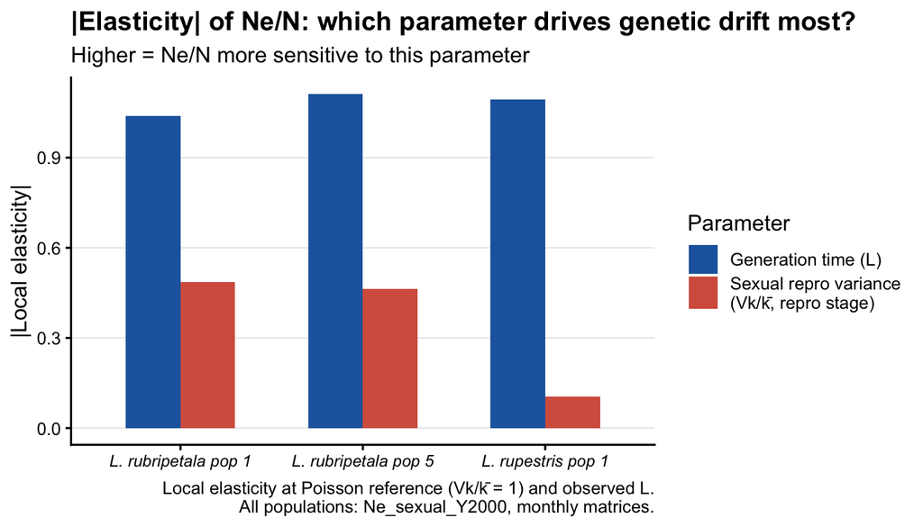

Absolute local elasticity of Ne/N with respect to two parameters across three populations. Larger bars indicate parameters where management intervention would have the greatest proportional effect on Ne/N.

```r
elast_long <- elast_tbl %>%
  select(Population, E_Vk_repro, E_L) %>%
  pivot_longer(cols = c(E_Vk_repro, E_L),
               names_to = "Parameter",
               values_to = "Elasticity") %>%
  mutate(
    Abs_E     = abs(Elasticity),
    Parameter = recode(Parameter,
                       E_Vk_repro = "Sexual repro variance\n(Vk/k̄, repro stage)",
                       E_L        = "Generation time (L)")
  )

ggplot(elast_long, aes(x = Population, y = Abs_E, fill = Parameter)) +
  geom_col(position = "dodge", width = 0.6) +
  scale_fill_manual(values = c("#2166ac", "#d6604d")) +
  scale_x_discrete(labels = function(x) gsub("\\*", "", x)) +
  labs(
    title    = "|Elasticity| of Ne/N: which parameter drives genetic drift most?",
    subtitle = "Higher = Ne/N more sensitive to this parameter",
    x        = NULL,
    y        = "|Local elasticity|",
    fill     = "Parameter",
    caption  = "Local elasticity at Poisson reference (Vk/k̄ = 1) and observed L.
                All populations: Ne_sexual_Y2000, monthly matrices."
  ) +
  theme_classic(base_size = 12) +
  theme(
    plot.title      = element_text(face = "bold"),
    axis.text.x     = element_text(face = "italic", size = 9),
    legend.position = "right",
    panel.grid.major.y = element_line(color = "grey92", linewidth = 0.4)
  )
```

# 7 Conservation prioritisation framework

The sensitivity analysis above leads to the following prioritisation framework for *Lepanthes* conservation, ordered by the expected genetic return on management investment.

## 7.1 Priority 1 — Reduce uncertainty in L

Generation time L is the most influential parameter in all three populations and the most poorly estimated. Monthly matrices from 16–34 months of data capture only 1–3 generation cycles for these long-lived orchids. A dedicated mark-recapture programme of at least 5 years per population would substantially reduce uncertainty in L and allow more confident Ne/N estimates.

## 7.2 Priority 2 — Equalise reproductive output in high-fecundity stages

The elasticity of Ne/N to Vk/k̄ is consistently negative and non-trivial. In *L. rupestris*, where stage 6 (multi-shoot adults) has the highest fecundity (F = 0.414/month), ensuring that these adults all contribute to the seed pool — via controlled hand-pollination in ex situ programmes, or by removing physical barriers to pollinator movement — would increase Ne/N.

## 7.3 Priority 3 — Augment census size in the lowest-Ne/N populations

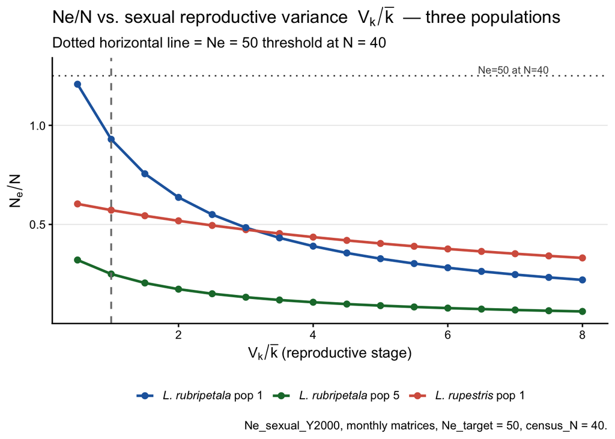

```r
df_final <- bind_rows(
  sens_Vk_Lrup1$data %>% mutate(Population = "*L. rupestris* pop 1"),
  sens_Vk_Lrub1$data %>% mutate(Population = "*L. rubripetala* pop 1"),
  sens_Vk_Lrub5$data %>% mutate(Population = "*L. rubripetala* pop 5")
)

ggplot(df_final, aes(x = Vk_over_k, y = NeN, color = Population)) +
  geom_line(linewidth = 1) +
  geom_point(size = 2) +
  geom_vline(xintercept = 1, linetype = "dashed",
             color = "grey50", linewidth = 0.7) +
  geom_hline(yintercept = 50/40, linetype = "dotted",
             color = "grey30", linewidth = 0.6) +
  annotate("text", x = 7.5, y = 50/40 + 0.03,
           label = "Ne=50 at N=40", hjust = 1, size = 3, color = "grey30") +
  scale_color_manual(
    values = c("#2166ac", "#1b7837", "#d6604d"),
    labels = c(
      expression(italic("L. rubripetala")~"pop 1"),
      expression(italic("L. rubripetala")~"pop 5"),
      expression(italic("L. rupestris")~"pop 1")
    )
  ) +
  labs(
    title    = expression(paste("Ne/N vs. sexual reproductive variance  ",
                                V[k]/bar(k), "  — three populations")),
    subtitle = "Dotted horizontal line = Ne = 50 threshold at N = 40",
    x        = expression(V[k]/bar(k)~"(reproductive stage)"),
    y        = expression(N[e]/N),
    color    = NULL,
    caption  = "Ne_sexual_Y2000, monthly matrices, Ne_target = 50, census_N = 40."
  ) +
  theme_classic(base_size = 12) +
  theme(
    plot.title      = element_text(face = "bold"),
    legend.position = "bottom",
    panel.grid.major.y = element_line(color = "grey92", linewidth = 0.4)
  )
```

# 9 References

- Caswell H. (2001). *Matrix Population Models*, 2nd ed. Sinauer Associates.
- Franklin I.R. (1980). Evolutionary change in small populations. In: Soulé & Wilcox, eds. *Conservation Biology*. Sinauer. pp. 135–149.
- Frankham R. (1995). Effective population size/adult population size ratios in wildlife: a review. *Genetical Research* **66**: 95–107.
- Lande R. (1995). Mutation and conservation. *Conservation Biology* **9**: 782–791.
- Morris W.F. & Doak D.F. (2002). *Quantitative Conservation Biology*. Sinauer Associates. Ch. 9.
- Tremblay R.L. & Ackerman J.D. (2001). Gene flow and effective population size in *Lepanthes* (Orchidaceae): a case for genetic drift. *Biological Journal of the Linnean Society* **72**: 47–62.
- Wright S. (1931). Evolution in Mendelian populations. *Genetics* **16**: 97–159.
- Yonezawa K., Ishida T. & Iwata H. (2000). Formulation and estimation of the effective size of stage-structured populations. *Evolution* **54**: 2007–2013.